# Tarea 1: Exploración y Visualización de Datos

Felipe Bravo, Hernán Sarmiento, Aymé Arango, Alison Fernandez, Cinthia Mabel Sanchez, Juan Pablo Silva

Septiembre 2020

# 1 Declaración de compromiso ético

Nosotros Francisco Molina y Rodrigo Oportot, declaramos que realizamos de manera grupal los pasos de la presente actividad. También declaramos no incurrir en copia, ni compartir nuestras respuestas con otras personas ni con otros grupos. Por lo que, ratificamos que las respuestas son de nuestra propia confección y reflejan nuestro propio conocimiento.

# 2 Instrucciones

1. Trabajen en equipos de dos o tres personas. Salvo excepciones, no se corregirá entregas con menos de dos integrantes.
2. Modifique este archivo `.Rmd` agregando sus respuestas donde corresponda.
3. Para cada pregunta, cuando corresponda, **incluya el código fuente que utilizó para llegar a su respuesta**.
4. El formato de entrega para esta actividad es un archivo html. **Genere un archivo HTML usando RStudio** y súbalo a U-Cursos. Basta con que uno de los integrantes haga la entrega. Si ambos hacen una entrega en U-Cursos, se revisará cualquiera de éstas.

# 3 Tarea

La primera parte de esta actividad son preguntas teóricas que avanzaron en las clases del curso de Minería de datos.

## 3.1 Teoría

*1. ¿Cuál es el objetivo de Minería de datos y qué la diferencia de Machine Learning? De un ejemplo.*

**Respuesta: El objetivo principal de la minería de datos es descubrir automáticamente información útil en grandes cantidades de datos, mediante diversas herramientas de varias disciplinas relativamente relacionadas, tales como la estadística, el reconocimiento de patrones en bases de datos que escapen de la magnitud abordable por el ojo humano o el almacenamiento y normalización de bases de datos. Mediante DM, se busca descubrir información útil, extrayendo conocimiento a través de automatizaciones (que pueden ser desarrolladas a partir de ML), permitiendo comprender dicha información de forma mucho más directa una vez ésta sea analizada por una persona. Por otro lado, podemos diferenciarla de Machine Learning en que éste último tiene como fin generar predicciones o preveer resultados esperables en base a datos e información previa, mediante el diseño, desarrollo y entrenamiento de algoritmos sin involucrarse directamente en el tipo de análisis que DM persigue de antemano, ya que dichos algoritmos pueden ser utilizados sobre distintos tipos de datos.**

*2. Describa y compare los siguientes métodos usados en Minería de datos: clasificación vs. clustering.*

**Respuesta: En primera instancia, podemos diferenciar entre métodos descriptivos y métodos predictivos: el primero busca encontrar patrones reconocibles e interpretables por humanos para describir los datos, mientras que el segundo busca predecir variables o datos desconocidas y/o futuras en base a información ya conocida.**

**La clasificación corresponde a un método predictivo, se toma un set de entrenamiento que incluye las etiquetas de clases y tiene por objetivo asignarle una clase a un nuevo elemento. Por otra parte, el clustering es un método descriptivo, que busca encontrar conjuntos de datos que sean similares entre sí, sin utilizar un conjunto de entrenamiento.**

*3. ¿Qué desafios existen en Minería de datos?*

**Respuesta: Hoy en día la minería de datos tiene varios desafíos: * Escalabilidad: Los modelos de DM deben funcionar tanto en baja escala como en gran escala. * Dimensionalidad: Se debe encontrar un punto de equilibrio entre trabajar con datasets de muchas dimensiones y de muy pocas dimensiones. Mientras más dimensiones tenga, más costoso es de trabajar, mientras que al tener menos dimensiones, más difícil es realizar análisis sobre él o encontrar patrones. * Datos complejos y heterogéneos: Se debe lidiar con datos que pueden no tener una estructura definida (complejos) y datos que de por sí sean muy distintos y que no permitan encontrar patrones (heterogéneos). * Privacidad: Qué tan privada puede llegar a ser la información presente en los datos públicos. * Calidad: Al trabajar con datos de la red usualmente se presentan muchas dificultades con respecto a su calidad: no están bien estructurados, no vienen separados de la manera correcta, faltan datos, hay desbalances, etc… * Streaming: Muchos de los datos con los que se trabaja hoy en día provienen de grandes volúmenes de datos que no tienen estructura alguna (YouTube, Facebook, Twitter), por lo que se vuelve costoso trabajar con ellos.**

*4. Respecto a los tipos de atributo, ¿cuál es la diferencia entre razón e intervalo?*

**Respuesta: Tanto los datos tipo razón como intervalo corresponden a tipos de datos cuantitativos. Su diferencia fundamental corresponde a que los datos del tipo intervalo no tienen definido un cero absoluto, mientras que los de razón sí. Ejemplos de datos tipo intervalo son: las fechas, temperatura en Celsius y temperatura en Farenheit, pues ninguno de estos datos tiene definido un cero absoluto. Por otra parte, ejemplos de datos tipo razón son: la hora, el largo y la temperatura en Kelvin, pues todos estos sí tienen definido un cero absoluto.**

*5. ¿Qué factores que ocasionan errores en el análisis de datos deben ser considerados para la limpieza de un set de datos?*

**Respuesta: El ruido (que corresponde a una componente aleatoria en la medición), los outliers o valores atípicos(objetos con características considerablemente diferentes a la mayoría), los valores faltantes (que pueden provenir de información no recolectada o atributos no aplicables a todos los grupos) y los datos duplicados.**

*6. ¿Qué es el análisis exploratorio de datos o EDA?*

**Respuesta: El análisis exploratorio de datos (EDA) es un conjunto de técnicas y herramientas empleadas en ciencias de los datos para analizar y comprender de manera eficiente y rápida la estructura y composición de un conjunto particular de datos sujetos a estudio. Se basa principalmente en resumir los datos mediante herramientas estadísticas para luego visualizarlos en herramientas gráficas que permitan una mejor comprensión de la información**

*7. Describa las medidas de tendencia central: media y mediana. Exponga la diferencia entre ambas.*

**Respuesta: Las medidas de tendencia central tratan de resumir los valores observados en un único valor asociado al valor localizado en el centro. La media corresponde al promedio aritmético entre los datos medidos, mientras que la mediana representa al dato que separa la mitad inferior de la mitad superior de las observaciones (está justo en el centro). Estas medidas suelen estar en valores muy cercanos entre sí, aunque no hay que fiarse de que éste será siempre el caso: la media es muy sensible a los outliers, mientras que la mediana no.**

*8. ¿Qué es una matriz de correlación y para qué sirve?*

**Respuesta: Una matriz de correlación es una herramienta matemática construida a partir de una matriz de dimensiones cuadradas, donde en sus filas se colocan una parte de los datos y en las columnas otra parte de ellos, comparándolos mediante un valor númerico real conocido como coeficiente de correlación de Pearson r(x,y) = cov(x,y)/(sd(x)sd(y)), con valores entre [-1, 1] para cada posición en la matriz (notar que r(x,x) = 1). Dependiendo del valor, se pueden notar distintas correlaciones entre los elementos: un valor negativo lejano a 0 implica una proporcionalidad inversa entre ellos; un valor en magnitud absoluta cercano a 0 implica ausencia de correlación lineal; un valor positivo lejano a 0 implica una proporcionalidad lineal directa. Es importante señalar que, aunque no haya correlación lineal, esto no implica que no existan otros tipos de correlaciones entre los datos (dígase exponencial o multiplicativa, por ejemplo).**

*9. Explique cómo se construye un Boxplot y exponga cómo se identifican los valores atípicos u outliers en este tipo de gráfico.*

**Respuesta: Los boxplots se construyen a partir de los percentiles. Se construye un rectángulo usando el primer y tercer cuartil como límites, de modo que la altura del rectángulo corresponde al rango inter-cuartil RIC; luego se traza una línea que divide al rectángulo en dos, correspondiente a la mediana; y finalmente se extiende cada extremo del rectángulo con brazos de largo Q1 - 1.5RIC para la inferior y Q3 + 1.5RIC para el superior. Los valores atípicos son aquellos que quedan fuera tanto del rectángulo como de sus brazos.**

##—————————————————————————————————————————————-##

## 3.2 Práctica

En esta parte de la actividad se trabajará con los datos del Proceso Constituyente 2016-2017 publicados en el Portal de Datos Abiertos del Gobierno de Chile, para mayor información pueden ingresar al siguiente link: https://datos.gob.cl/dataset/proceso-constituyente-abierto-a-la-ciudadania. Los datos corresponden a las actas de los Encuentros Locales Autoconvocados (ELAs), en cada cual, un grupo de personas se reune a discutir distintos conceptos como por ejemplo: salud, educación, seguridad, etc.

Los datos con los que trabajarán consisten en la cantidad de veces que cada concepto constitucional fue mencionado por cada localidad de Chile.

Para cargar los datos, use:

```r
data_tf <- read.csv("http://dcc.uchile.cl/~hsarmien/mineria/datasets/actas.txt", header = T)
```

**Por cada pregunta adjunte el código R que utilizó para llegar a la respuesta. Respuestas sin código no recibirán puntaje**

### 3.2.1 Exploración básica

1. ¿Cuáles son las dimensiones del dataset (filas, columnas)? Adjunte código o indique cómo determinó la cantidad de datos total.

El dataset “data_tf” tiene 328 filas y 113 columnas.

```r
dim(data_tf)
```

```
## [1] 328 113
```

2. ¿Qué describe cada línea del dataset? (ejemplifique tomando la fila 85)

Cada fila describe los resultados de cada encuentro local autoconvocado, cada columna representa la cantidad de veces que apareció un concepto respondiendo a alguna de las preguntas de la ELA por parte de los ciudadanos. En particular, la fila 85 muestra los resultados del ELA en la ciudad de Andacollo, ubicada en la provincia de Elqui, perteneciente a la región de Coquimbo; y a primera vista se observa que se mencionaron conceptos como derechos: la educación, la integridad física y psiquica, la nacionalidad, la salud, etc…

```r
data_tf[85,]
```

```
##                   localidad a_huelga a_la_educacion a_la_honra._al_honor
## 85 Coquimbo/Elqui/Andacollo        0              1                    0
##    a_la_identidad_cultural a_la_informacion a_la_integracion_de_discapacidad
## 85                       0                0                                0
##    a_la_integridad_fisica_y_psiquica a_la_nacionalidad a_la_participacion
## 85                                 1                 1                  0
##    a_la_salud a_la_seguridad.vida_sin_violencia a_la_seguridad_social a_la_vida
## 85          2                                 0                     0         0
##    a_la_vivienda_digna a_sindicalizarse_y_a_la_negociacion_colectiva
## 85                   1                                             0
##    a_sufragio.votar acceso_a_informacion_publica acceso_a_la_cultura
## 85                2                            0                   0
##    al_salario_equitativo al_trabajo amistad_civica autonomia.libertad
## 85                     0          1              2                  0
##    bien_comun.comunidad cambio_o_reforma_constitucional ciudadania
## 85                    0                               0          0
##    congreso_o_parlamento_.estructura_y_funciones.
## 85                                              2
##    contraloria_general.tribunales_de_cuentas cumplimiento_de_las_leyes_y_normas
## 85                                         1                                  2
##    cumplimiento_de_obligaciones_fiscales
## 85                                     0
##    cumplimiento_de_tratados_y_obligaciones_internacionales
## 85                                                       2
##    de_los_pueblos_indigenas de_peticion_ante_las_autoridades de_propiedad
## 85                        1                                0            0
##    de_proteccion_y_conservacion_de_patrimonio_historico_y_cultural
## 85                                                               3
##    de_satisfacer_cargas_publicas
## 85                             1
##    deberes_de_proteccion_de_conservacion_de_la_naturaleza
## 85                                                      3
##    defensor_del_pueblo.ciudadano democracia derecho_de_asociacion
## 85                             0          1                     0
##    derechos_del_nino._nina_y_adolescente desarrollo descentralizacion dignidad
## 85                                     0          0                 1        2
##    diversidad division_territorial
## 85          0                    0
##    ejercicio_legitimo_y_no_abusivo_de_los_derechos emprendimiento_libre
## 85                                               1                    0
```

[output cut: 33 more lines]

```
## 85                      0        0                                   0
##    proteccion._promocion_y_respeto_de_los_derechos_humanos_y_fundamentales
## 85                                                                       2
##    republica respeto respeto.conservacion_de_la_naturaleza_o_medio_ambiente
## 85         0       2                                                      3
##    respeto_a_la_naturaleza.medio_ambiente respeto_de_derechos_de_otros
## 85                                      2                            3
##    respeto_por_la_constitucion responsabilidad reunion_pacifica
## 85                           4               0                0
##    regimen_de_gobierno_presidencial.semi.presidencial.parlamentario seguridad
## 85                                                                1         1
##    ser_elegido_en_cargos_publicos servicio_a_la_comunidad soberania solidaridad
## 85                              1                       1         0           0
##    subsidiaridad tolerancia transparencia_y_publicidad unidad
## 85             0          0                          0      0
```

3. ¿Existen localidades repetidas en el dataset? Adjunte el código o indique cómo llegó a esa conclusión.

En la pregunta (1) se estableció que el dataset tiene 328 filas, y la función unique muestra 328 resultados distintos para la categoría “localidad”. Por lo tanto no hay localidades repetidas.

```r
unique(data_tf["localidad"])
```

```
##                                                                      localidad
## 1                        Aisen del General Carlos Ibanez del Campo/Aysen/Aysen
## 2              Aisen del General Carlos Ibanez del Campo/Capitan Prat/Cochrane
## 3             Aisen del General Carlos Ibanez del Campo/Capitan Prat/O'higgins
## 4                Aisen del General Carlos Ibanez del Campo/Capitan Prat/Tortel
## 5                Aisen del General Carlos Ibanez del Campo/Coyhaique/Coyhaique
## 6               Aisen del General Carlos Ibanez del Campo/Coyhaique/Lago Verde
## 7        Aisen del General Carlos Ibanez del Campo/General Carrera/Chile Chico
## 8         Aisen del General Carlos Ibanez del Campo/General Carrera/Rio Ibanez
## 9                                          Antofagasta/Antofagasta/Antofagasta
## 10                                          Antofagasta/Antofagasta/Mejillones
## 11                                        Antofagasta/Antofagasta/Sierra Gorda
## 12                                              Antofagasta/Antofagasta/Taltal
## 13                                                   Antofagasta/El Loa/Calama
## 14                                     Antofagasta/El Loa/San Pedro de Atacama
```

[output cut: 314 more lines]

4. Liste los nombres de las columnas del dataset `data_tf`. Adjunte código en R y *recuerde* usar `head` si el resultado es muy largo.

Dado que hay 113 columnas, se muestran las primeras 6 usando la función head:

```r
head(colnames(data_tf))
```

```
## [1] "localidad"               "a_huelga"
## [3] "a_la_educacion"          "a_la_honra._al_honor"
## [5] "a_la_identidad_cultural" "a_la_informacion"
```

### 3.2.2 Análisis

1. Liste todas las localidades donde *no* se discutió el concepto `a_la_salud`.

En sólo 17 localidades no fue discutido el concepto “a_la_salud”:

```r
data_tf[data_tf$a_la_salud == 0,c("localidad")]
```

```
##  [1] "Aisen del General Carlos Ibanez del Campo/Capitan Prat/O'higgins"
##  [2] "Antofagasta/El Loa/San Pedro de Atacama"
##  [3] "Arica y Parinacota/Arica/Camarones"
##  [4] "Biobio/Bio Bio/Alto Biobio"
##  [5] "Biobio/Bio Bio/Laja"
##  [6] "Biobio/Bio Bio/Negrete"
##  [7] "Biobio/Concepcion/Santa Juana"
##  [8] "Biobio/Nuble/San Fabian"
##  [9] "La Araucania/Malleco/Ercilla"
## [10] "Los Lagos/Osorno/Puerto Octay"
## [11] "Los Rios/Ranco/Futrono"
## [12] "Los Rios/Valdivia/Corral"
## [13] "Magallanes y de la Antartica Chilena/Tierra del Fuego/Timaukel"
## [14] "Maule/Talca/Empedrado"
## [15] "Tarapaca/El Tamarugal/Camina"
## [16] "Valparaiso/Quillota/Hijuelas"
## [17] "Valparaiso/Valparaiso/Juan Fernandez"
```

2. Liste las 10 localidades que más mencionaron el concepto `justicia`.

Se obtuvieron ordenando según la columna justicia de modo descendiente:

```r
data_tf[order(-data_tf$justicia),c("localidad","justicia")][0:10,]
```

```
##                                            localidad justicia
## 276      Metropolitana de Santiago/Santiago/Santiago      230
## 267   Metropolitana de Santiago/Santiago/Providencia      165
## 278         Metropolitana de Santiago/Santiago/Nunoa      145
## 259    Metropolitana de Santiago/Santiago/Las Condes      132
## 237 Metropolitana de Santiago/Cordillera/Puente Alto      130
## 327                 Valparaiso/Valparaiso/Valparaiso      105
## 255    Metropolitana de Santiago/Santiago/La Florida      103
## 328               Valparaiso/Valparaiso/Vina del Mar       80
## 9                Antofagasta/Antofagasta/Antofagasta       72
## 290                         Tarapaca/Iquique/Iquique       72
```

3. Liste los 10 conceptos menos mencionados a lo largo de todo el proceso.

Para poder sumar las filas por columnas se deja afuera la columna de “localidad”, llamando a data_tf[2:113], luego se aplica la función colSums, que realiza sumatorias en las columnas restantes. Finalmente se aplica la función sort sobre lo anterior y se limita a 10 resultados, obteniéndose así los 10 conceptos mencionados a lo larto del proceso junto a su cantidad de apariciones:

```r
sort(colSums(data_tf[2:113]))[0:10]
```

```
## igualdad_ante_las_cargas_publicas              libertad_ambulatoria
##                                31                                56
##              a_la_honra._al_honor                  reunion_pacifica
##                                64                                65
##  de_peticion_ante_las_autoridades                       patriotismo
##                                67                               101
##        igualdad_ante_los_tributos                            unidad
##                               111                               123
##                 a_la_nacionalidad    ser_elegido_en_cargos_publicos
##                               129                               159
```

4. Liste las 10 localidades que más participaron en el proceso. Describa cómo definió su medida de participación.

```r
# RESPUESTA: Definimos nuestro criterio de participación en base al total de la suma de los conceptos discutidos por asamblea, lo que sería básicamente un conteo de frecuencias.

sum_rows = rowSums(data_tf[2:113])
localities = data_tf$localidad
aux_df = data.frame(localidad = localities, total = sum_rows)
sorted_df <- aux_df[order(-aux_df$total),]
head(sorted_df, 10)
```

```
##                                            localidad total
## 276      Metropolitana de Santiago/Santiago/Santiago 12448
## 267   Metropolitana de Santiago/Santiago/Providencia 10234
## 278         Metropolitana de Santiago/Santiago/Nunoa  7675
## 259    Metropolitana de Santiago/Santiago/Las Condes  6608
## 327                 Valparaiso/Valparaiso/Valparaiso  5252
## 237 Metropolitana de Santiago/Cordillera/Puente Alto  4956
## 255    Metropolitana de Santiago/Santiago/La Florida  4036
## 258      Metropolitana de Santiago/Santiago/La Reina  4023
## 328               Valparaiso/Valparaiso/Vina del Mar  3374
## 112                       La Araucania/Cautin/Temuco  3052
```

5. Ejecute el siguiente código que permitirá agregar una nueva columna a nuestro dataframe que solo tendrá el nombre de la región.

```r
library(dplyr)
regiones <- strsplit(as.character(data_tf[,1]), '/')
data_tf$region <- sapply(regiones, "[[", 1)
data_tf <- data_tf %>% select(localidad, region, everything())
```

Luego, genere un gráfico de barras (ggplot) que muestre los 10 conceptos más mencionados en cada una de las regiones mencionadas (adjunte gráficos y código):

- `Atacama`
- `Coquimbo`
- `Metropolitana de Santiago`

Cabe resaltar, que se esperan tres gráficos de barras para las tres diferentes regiones:

```r
library(stringr)
texto = function(x){
  str_to_title(str_replace_all(x,"_", "\n"))
}
```

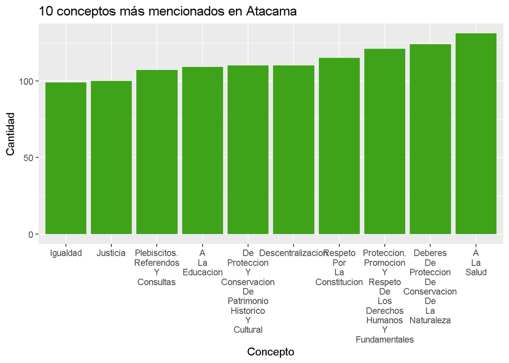

```r
# 10 conceptos más mencionados en Atacama
topAtacama = as.data.frame(sort(colSums(data_tf[data_tf$region == "Atacama",][3:113]),decreasing = TRUE)[0:10])
colnames(topAtacama) = c("Apariciones")

library(ggplot2)

ggplot(topAtacama) +   # asociamos un data frame a ggplot
  geom_bar(aes(x = reorder(rownames(topAtacama),Apariciones), y = Apariciones), stat="identity", fill = "#3fa31a", space = 3) +   # creamos un grafico de barras como una capa
  #coord_flip() +  # transformamos el grafico invirtiendo los ejes de coordenadas (sólo visualmente)
  ggtitle("10 conceptos más mencionados en Atacama") + # título
  xlab("Concepto") + ylab("Cantidad") + # etiquetas
  scale_x_discrete(labels = texto)
```

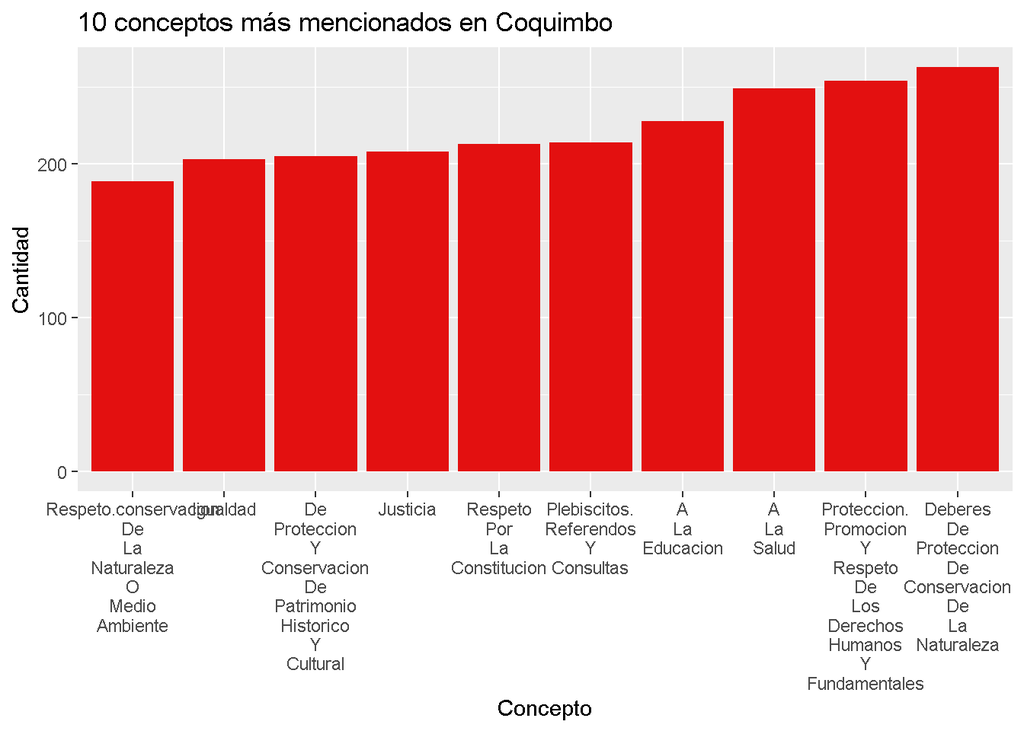

```r
# 10 conceptos más mencionados en Coquimbo
topCoquimbo = as.data.frame(sort(colSums(data_tf[data_tf$region == "Coquimbo",][3:113]),decreasing = TRUE)[0:10])
colnames(topCoquimbo) = c("Apariciones")

library(ggplot2)

ggplot(topCoquimbo) +   # asociamos un data frame a ggplot
  geom_bar(aes(x = reorder(rownames(topCoquimbo),Apariciones), y = Apariciones), stat="identity", fill = "#e31010", space = 3) +   # creamos un grafico de barras como una capa
  #coord_flip() +  # transformamos el grafico invirtiendo los ejes de coordenadas (sólo visualmente)
  ggtitle("10 conceptos más mencionados en Coquimbo") + # título
  xlab("Concepto") + ylab("Cantidad") + # etiquetas
  scale_x_discrete(labels = texto)
```

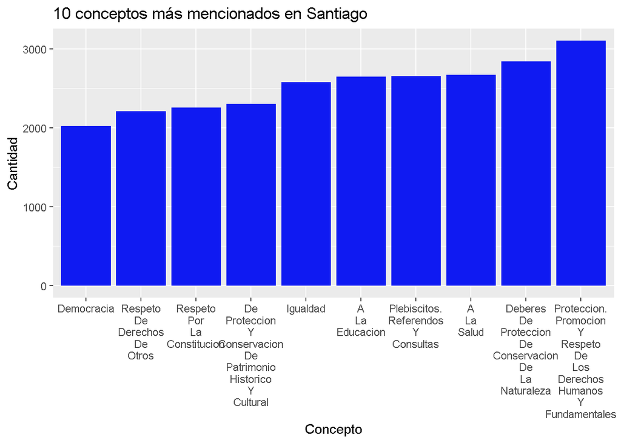

```r
# 10 conceptos más mencionados en Santiago
topSantiago = as.data.frame(sort(colSums(data_tf[data_tf$region == "Metropolitana de Santiago",][3:113]),decreasing = TRUE)[0:10])
colnames(topSantiago) = c("Apariciones")

library(ggplot2)

ggplot(topSantiago) +   # asociamos un data frame a ggplot
  geom_bar(aes(x = reorder(rownames(topSantiago),Apariciones), y = Apariciones), stat="identity", fill = "#0f1af2", space = 3) +   # creamos un grafico de barras como una capa
  #coord_flip() +  # transformamos el grafico invirtiendo los ejes de coordenadas (sólo visualmente)
  ggtitle("10 conceptos más mencionados en Santiago") + # título
  xlab("Concepto") + ylab("Cantidad") + # etiquetas
  scale_x_discrete(labels = texto)
```

6. De la pregunta anterior, ¿considera que es razonable usar el conteo de frecuencias para determinar las regiones que tuvieron mayor participación en el proceso? ¿Por qué? Sugiera y solamente comente una forma distinta de hacerlo.

```r
# RESPUESTA: No es razonable para determinar la participación a nivel nacional, dado que distintas regiones tienen distintos tamaños de población. Por lo que regiones con menos participación pero más habitantes podrían dominar el conteo de frecuencias. Una alternativa mejor sería normalizar dicho conteo de frecuencias dividiendo por el total de población de cada región. De ese modo se podría evaluar por porcentajes de población, permitiéndole representación a las regiones con menor población.
```

## 3.3 Ejercicios

### 3.3.1 Accidentes de tránsito

Para esta sección utilizaremos un dataset real de número de accidentes de tránsito por localidad, el cual puede ser encontrado en el siguiente link: http://datos.gob.cl/dataset/9348. Para cargar el dataset ejecute el siguiente código:

```r
tipos <- read.table("https://users.dcc.uchile.cl/~hsarmien/mineria/datasets/accidentes_2010_2011.txt")
head(tipos)
```

```
##    Muestra                   Descripcion Anio TipoAccidente Cantidad
## 1 Nacional                      Nacional 2010     Atropello     8247
## 2 Nacional                      Nacional 2011     Atropello     8339
## 3 Regional XV RegiÃ³n Arica y Parinacota 2010     Atropello      115
## 4 Regional XV RegiÃ³n Arica y Parinacota 2011     Atropello      159
## 5  Comunal                         ARICA 2010     Atropello      115
## 6  Comunal                         ARICA 2011     Atropello      158
```

Explore el set de datos para responder las siguientes preguntas:

1. Filtre los datos para incluir sólo los accidentes ocurridos el año 2011 a nivel regional. Genere un boxplot donde se indique la cantidad de accidentes categorizado por tipo de accidente.

Este tipo de gráfico nos ayudará a entender como se distribuye los datos por cada tipo de accidentes. Es decir, podremos apreciar que tan dispersos o similares son los datos en todo el dataset. También, puede ser útil para observar valores atípicos u outliers en los datos.

Se ajustaron los límites del eje Y para ignorar a los outliers que distorsionaban la escala:

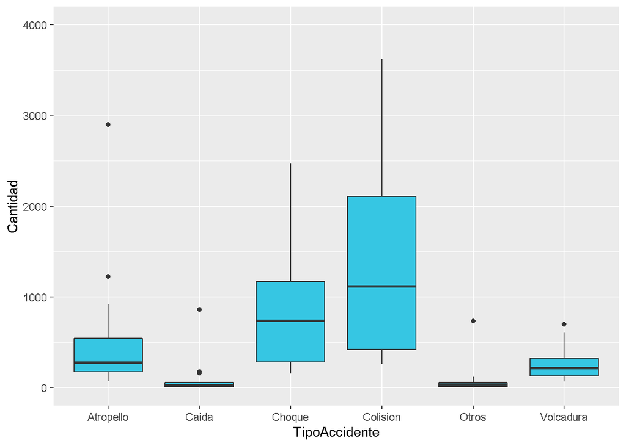

```r
regional_2011 = tipos[tipos$Anio == 2011 & tipos$Muestra == "Regional",]
ggplot(regional_2011, aes(TipoAccidente,Cantidad))+
  geom_boxplot(notch=FALSE, fill = "#36c6e3")+
  coord_cartesian(ylim = c(0, 4000))
```

2. ¿Qué aprecia con el gráfico anterior? ¿Qué otra forma de explorar los datos podría agregar? ¿Qué información adicional aporta? Adjunte una breve explicación.

**Respuesta: Se observan los distintos tipos de accidentes de tránsito y sus cantidades en función de lo pedido en el enunciado. Se puede notar que la mayoría de los accidentes corresponden a colisiones entre vehículos. Al analizar los datos en su forma matricial (filas y columnas), podemos observar que la Región Metropolitana acapara las mayores cantidades en los distintos tipos de accidentes; esto puede deberse a la mayor concentración y número de habitantes y vehículos, en comparación con las otras regiones del país. No obstante, junto con responder la segunda pregunta, hay otros factores por considerar para explorar nuevamente los datos: la proporción de accidentes en función del número de habitantes por cada región, ya que se evidencia cómo la RM altera significativamente la información gráfica al actuar como un outlier, por lo que se podría explorar el dataset apartando a la RM en un análisis separado. Hay que tener en cuenta que otro factor de suma importancia en los accidentes de tránsito es la calidad, competencia y responsabilidad de los conductores, dependiendo esto del grado de fiscalización con que se evalúen los exámenes de conducir, así como el cumplimiento de las leyes de tránsito dentro de las regiones. Una mejor fiscalización y multas más severas para los infractores puede reducir el número de accidentes en el lugar donde dichas condiciones se apliquen, afectando así los datos. Con todo esto en cuenta, si se analiza la RM por separado del resto de las regiones, considerando sus proporciones de ciudadanos y/o vehículos, podrían observarse diferencias sustanciales: quizá en la RM los ciudadanos “conducen mejor” porque la proporción de accidentes en función de ciudadanos y/o vehículos es menor (recalcando que esto es una suposición), sustentándose en el hipotético hecho de que se fiscaliza con más intensidad en tal región, entre otras posibles observaciones que puedan surgir.**

### 3.3.2 Diamantes

Considere el set de datos diamonds del paquete ggplot2 de R, que contiene los precios en dolares, junto con otros atributos importantes: quilates, corte, color y claridad. También hay medidas físicas como ser: x (largo), y (ancho), z (profundidad), depth (porcentaje total de profundidad) y table (ancho desde el tope del diamante al punto relativo más ancho del diamante):

```r
library(ggplot2)
data("diamonds")
head(diamonds)
```

```
## # A tibble: 6 x 10
##   carat cut       color clarity depth table price     x     y     z
##   <dbl> <ord>     <ord> <ord>   <dbl> <dbl> <int> <dbl> <dbl> <dbl>
## 1 0.23  Ideal     E     SI2      61.5    55   326  3.95  3.98  2.43
## 2 0.21  Premium   E     SI1      59.8    61   326  3.89  3.84  2.31
## 3 0.23  Good      E     VS1      56.9    65   327  4.05  4.07  2.31
## 4 0.290 Premium   I     VS2      62.4    58   334  4.2   4.23  2.63
## 5 0.31  Good      J     SI2      63.3    58   335  4.34  4.35  2.75
## 6 0.24  Very Good J     VVS2     62.8    57   336  3.94  3.96  2.48
```

Realice una exploración por el set de datos para responder las siguientes preguntas:

1. Teniendo en cuenta las medidas físicas, ¿considera que existen valores inexistentes o inconsistentes? Describa como manejaría esta situación. Adjunte el código necesario.

**Respuesta: Primero podemos filtrar buscando filas que tengan valores N/A. Luego, podemos revisar si las dimensiones indicadas son consistentes con la realidad. Por ejemplo, no pueden haber diamantes en dimensiones menores a 3, dada la naturaleza de nuestra realidad. En el caso de que sí hubieran, esto representaría una inconsistencia con la información del dataframe. Es por esto que podemos buscar valores mínimos o máximos en las dimensiones como primer acercamiento.**

```r
# RESPUESTA

#Revisar valores inexistentes
non_existant = sum(is.na(diamonds))
non_existant
```

```
## [1] 0
```

```r
# Resulta que no hay valores nulos en el dataframe, por lo que queda analizar las dimensiones de forma más específica. Partiremos revisando los valores mínimos que toman las dimensiones de los diamantes.

#Revisaremos con Summary a ver qué aparece.
summary(diamonds)
```

```
##      carat               cut        color        clarity          depth
##  Min.   :0.2000   Fair     : 1610   D: 6775   SI1    :13065   Min.   :43.00
##  1st Qu.:0.4000   Good     : 4906   E: 9797   VS2    :12258   1st Qu.:61.00
##  Median :0.7000   Very Good:12082   F: 9542   SI2    : 9194   Median :61.80
##  Mean   :0.7979   Premium  :13791   G:11292   VS1    : 8171   Mean   :61.75
##  3rd Qu.:1.0400   Ideal    :21551   H: 8304   VVS2   : 5066   3rd Qu.:62.50
##  Max.   :5.0100                     I: 5422   VVS1   : 3655   Max.   :79.00
##                                     J: 2808   (Other): 2531
##      table           price             x                y
##  Min.   :43.00   Min.   :  326   Min.   : 0.000   Min.   : 0.000
##  1st Qu.:56.00   1st Qu.:  950   1st Qu.: 4.710   1st Qu.: 4.720
##  Median :57.00   Median : 2401   Median : 5.700   Median : 5.710
##  Mean   :57.46   Mean   : 3933   Mean   : 5.731   Mean   : 5.735
##  3rd Qu.:59.00   3rd Qu.: 5324   3rd Qu.: 6.540   3rd Qu.: 6.540
##  Max.   :95.00   Max.   :18823   Max.   :10.740   Max.   :58.900
##
##        z
##  Min.   : 0.000
##  1st Qu.: 2.910
##  Median : 3.530
##  Mean   : 3.539
##  3rd Qu.: 4.040
##  Max.   :31.800
##
```

```r
#Podemos  notar que para las dimensiones x, y o z, hay valores iguales 0, así como valores demasiado grandes para una escala en centímetros. Respecto a cualquiera de los 3 valores iguales a 0, son dimensiones imposibles de concebir en una realidad de 3 dimensiones. Análogamente, sucede lo mismo con valores demasiado grandes. Veremos algunas de las filas en detalle que presentan valores iguales a 0 en x, y o z.
head(diamonds[diamonds$x == 0 | diamonds$y == 0 | diamonds$z == 0,])
```

```
## # A tibble: 6 x 10
##   carat cut     color clarity depth table price     x     y     z
##   <dbl> <ord>   <ord> <ord>   <dbl> <dbl> <int> <dbl> <dbl> <dbl>
## 1  1    Premium G     SI2      59.1    59  3142  6.55  6.48     0
## 2  1.01 Premium H     I1       58.1    59  3167  6.66  6.6      0
## 3  1.1  Premium G     SI2      63      59  3696  6.5   6.47     0
## 4  1.01 Premium F     SI2      59.2    58  3837  6.5   6.47     0
## 5  1.5  Good    G     I1       64      61  4731  7.15  7.04     0
## 6  1.07 Ideal   F     SI2      61.6    56  4954  0     6.62     0
```

```r
#Siendo un total de 20 filas
nrow(diamonds[diamonds$x == 0 | diamonds$y == 0 | diamonds$z == 0,])
```

```
## [1] 20
```

```r
#Respecto a los diamantes con algún valor en sus dimensiones demasiado grande, podemos calcular la desviación estándar de cada dimensión y revisar aquellas filas que posean algún valor de x, y o z que se aleje sustancialmente de una cota razonable definida a partir de dicha desviación. Por ejemplo, podríamos buscar las filas que posean alguna de sus dimensiones más allá de 9 veces la desviación estándar de tal dimensión.

#Primero calcularemos la desviación estándar de cada dimensión y la amplificaremos por un factor arbitrario.
f = 9 # factor multiplicativo para la desviación estándar
sd_x = sd(diamonds$x) * f
sd_y = sd(diamonds$y) * f
sd_z = sd(diamonds$z) * f


#Ahora buscaremos las filas donde hayan dimensiones que se alejen más de f veces la desviación estándar respectiva a ellas. Mostraremos solo algunas de ellas.
head(diamonds[diamonds$x > sd_x | diamonds$y > sd_y | diamonds$z > sd_z,])
```

```
## # A tibble: 6 x 10
##   carat cut     color clarity depth table price     x     y     z
##   <dbl> <ord>   <ord> <ord>   <dbl> <dbl> <int> <dbl> <dbl> <dbl>
## 1  3.65 Fair    H     I1       67.1    53 11668  9.53  9.48  6.38
## 2  2    Premium H     SI2      58.9    57 12210  8.09 58.9   8.06
## 3  4.01 Premium I     I1       61      61 15223 10.1  10.1   6.17
## 4  4.13 Fair    H     I1       64.8    61 17329 10     9.85  6.43
## 5  5.01 Fair    J     I1       65.5    59 18018 10.7  10.5   6.98
## 6  4.5  Fair    J     I1       65.8    58 18531 10.2  10.2   6.72
```

```r
#Podemos notar la primera inconsistencia de este tipo, donde hay un diamante con una dimensión en y igual a 58.90. Aunque hiciéramos el supuesto de tomarlo como consistente, éste sería mucho más grande que el diamante de igual corte "Premium" de dimensiones (10.14, 10.10, 6.17), pero vale aprox. 3000 menos, lo cual es extraño e inconsistente.
```

```r
#Para abordar estas inconsistencias, hay varios caminos que seguir: en primer lugar, podemos derechamente eliminar las filas inconsistentes según los criterios definidos anteriormente, ya que son pocas en comparació al volumen original del dataframe. Por otro lado, siguiendo una ruta más compleja, se podría definir un tamaño hipotético esperable para los diamantes en función de los datos realmente consistentes, con el fin de rellenar los valores iguales a 0 para los diamantes inconsistentes. Respecto a los valores demasiado grandes, se podría hacer lo mismo, reduciendo tales valores, pero sería más complejo ya que habría que definir una cota, como se mencionó en el apartado anterior. El camino más sencillo es simplemente eliminar los datos inconsistentes, ya que son pocos.

#Podemos crear un nuevo dataframe (para no editar el de la tarea) eliminando los valores que tengan 0 y luego los valores que sean demasiado grandes, usando la libreria dplyr:
library(tidyverse)
library(dplyr)

diamonds2<-diamonds %>%
  filter(!((diamonds$x == 0 | diamonds$y == 0 | diamonds$z == 0)) & !(diamonds$x > sd_x | diamonds$y > sd_y | diamonds$z >sd_z))
diamonds2
```

```
## # A tibble: 53,912 x 10
##    carat cut       color clarity depth table price     x     y     z
##    <dbl> <ord>     <ord> <ord>   <dbl> <dbl> <int> <dbl> <dbl> <dbl>
##  1 0.23  Ideal     E     SI2      61.5    55   326  3.95  3.98  2.43
##  2 0.21  Premium   E     SI1      59.8    61   326  3.89  3.84  2.31
##  3 0.23  Good      E     VS1      56.9    65   327  4.05  4.07  2.31
##  4 0.290 Premium   I     VS2      62.4    58   334  4.2   4.23  2.63
##  5 0.31  Good      J     SI2      63.3    58   335  4.34  4.35  2.75
##  6 0.24  Very Good J     VVS2     62.8    57   336  3.94  3.96  2.48
##  7 0.24  Very Good I     VVS1     62.3    57   336  3.95  3.98  2.47
##  8 0.26  Very Good H     SI1      61.9    55   337  4.07  4.11  2.53
##  9 0.22  Fair      E     VS2      65.1    61   337  3.87  3.78  2.49
## 10 0.23  Very Good H     VS1      59.4    61   338  4     4.05  2.39
## # ... with 53,902 more rows
```